# Exercise 11.3

### Model with 1 hidden layer and 5 nodes

```r
set.seed(1)
ntw_1h_5n <- neuralnet(Price ~., data= train.norm.df, linear.output = T, hidden=5)
#we set linear.output to TRUE because we do not want to apply act.fct, in fact we did not scaled data within [-1,1]
ntw_1h_5n$weights
```

```
## [[1]]
## [[1]][[1]]
##          [,1]    [,2]    [,3]   [,4]    [,5]
##  [1,] -0.3136  0.9432 -1.3821 -0.622  0.1668
##  [2,]  0.2844  6.7727 -0.4284 -1.134  2.1755
##  [3,]  0.1378  0.3345 -0.4422 -0.522  0.9723
##  [4,]  1.1685 -2.2323 -0.8886  3.078  0.5889
##  [5,] -0.7955 -1.9299  1.5078  9.514  1.4567
##  [6,] -0.5777 -0.6332  0.6623 -0.604 -0.6514
##  [7,]  0.0226 -0.7631  0.0195 -0.914 -1.6129
##  [8,]  0.2419  0.4108 -0.2538  0.820  0.1672
##  [9,] -0.4002  0.8669  4.2071  6.258  1.9817
## [10,] -0.5034  0.4400  0.3188  2.321 -0.4688
## [11,]  2.0989  0.5705 -2.0118 -0.123  1.2452
## [12,]  0.0475  0.0759 -0.0150  0.642  0.0317
## [13,] -0.3108 -0.9086  0.4902  0.043 -0.1570
## [14,] -0.5216 -0.3529  1.5408  0.607  0.2846
## [15,]  0.0254 -0.8018 -0.0964 -0.420  0.0333
## [16,] -0.3010  0.5578  0.8327 -3.462 -1.5213
## [17,]  0.1793 -0.3162  1.2363 -1.870  0.0613
##
## [[1]][[2]]
##        [,1]
## [1,]  0.328
## [2,]  0.744
## [3,] -0.314
## [4,]  0.300
## [5,]  0.168
## [6,] -0.458
```

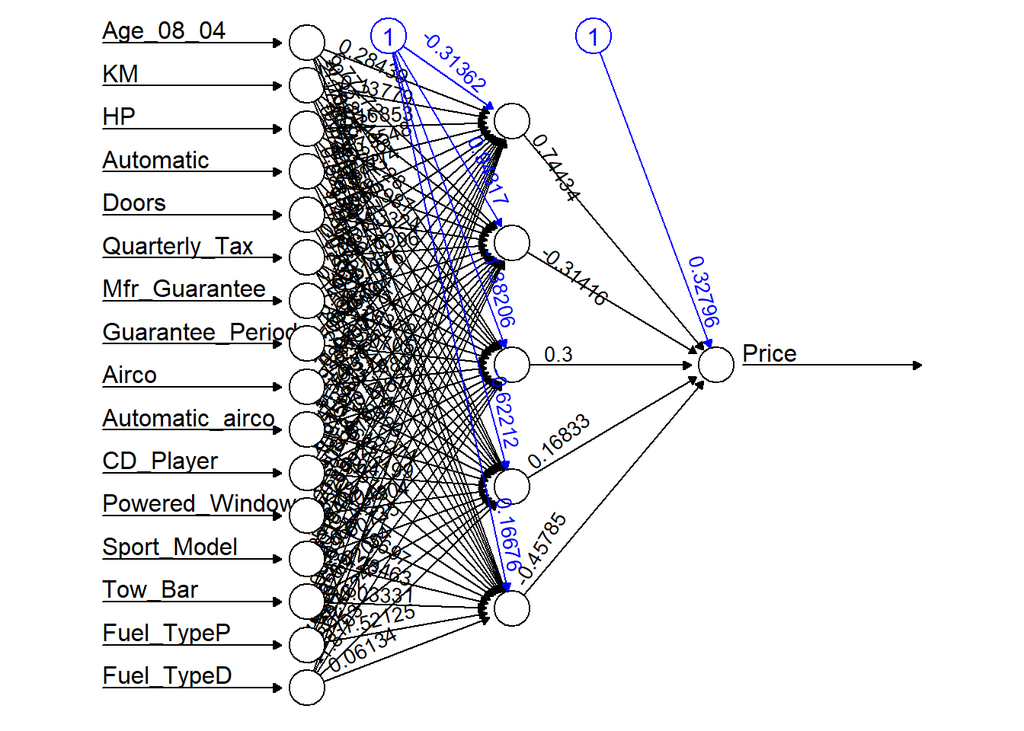

```r
plot(ntw_1h_5n, rep = "best") # plot the networks
```

```r
#Prediction on the two sets and rescaling of the values
ntw15_pred_t <- predict(ntw_1h_5n, train.norm.df)
ntw15_pred_v <- predict(ntw_1h_5n, valid.norm.df)

min_value<-min(train.df$Price)
max_value <- max(train.df$Price)

#Rescaling the data and predictions
rescaled_price_15<- data.table("Records_t" = train.norm.df$Price, "Predictions_t" = ntw15_pred_t ,"Records_v" = valid.norm.df$Price, "Predictions_v" = ntw15_pred_v)
rescaled_price_15 <- rescaled_price_15[, Records_t := Records_t*(max_value -  min_value) + min_value ] #re-scale the Records
rescaled_price_15 <- rescaled_price_15[, Predictions_t.V1 := Predictions_t.V1*(max_value -min_value) + min_value] #re-scale the Predictions
rescaled_price_15 <- rescaled_price_15[, Records_v := Records_v*(max_value -  min_value) + min_value ] #re-scale the Records
rescaled_price_15 <- rescaled_price_15[, Predictions_v.V1 := Predictions_v.V1*(max_value -min_value) + min_value] #re-scale the Predictions
rescaled_price_15 <- rescaled_price_15[, Residuals_t := Records_t - Predictions_t.V1] #compute the residuals and add a column
rescaled_price_15 <- rescaled_price_15[, Residuals_v := Records_v - Predictions_v.V1]
head(rescaled_price_15)
```

```
##    Records_t Predictions_t.V1 Records_v Predictions_v.V1 Residuals_t
## 1:      9250             8862      8490             8517       387.9
## 2:      9895             8939      7500             8148       955.7
## 3:     17950            17762      9950            10094       188.4
## 4:      9995            10067     11500            10746       -71.9
## 5:     10900            10871      8750             8573        29.1
## 6:     13995            13871     11450            10773       123.6
##    Residuals_v
## 1:       -27.3
## 2:      -647.6
## 3:      -143.8
## 4:       754.1
## 5:       177.0
## 6:       677.2
```

Accuracy measures:

```r
options(scipen=999, digits=3) #positive values towards fixed and negative towards scientific notation, 3 significant values
acc_15_train<- data.frame(accuracy(rescaled_price_15$Predictions_t.V1, rescaled_price_15$Records_t))
acc_15_val<-data.frame(accuracy(rescaled_price_15$Predictions_v.V1, rescaled_price_15$Records_v))

kable(acc_15_train, row.names = F)%>% kable_paper("hover", full_width = T) #presentation
```

| ME | RMSE | MAE | MPE | MAPE |
| --- | --- | --- | --- | --- |
| -0.144 | 1001 | 771 | -1.03 | 7.8 |

```r
kable(acc_15_val, row.names = F)%>% kable_paper("hover", full_width = T) #presentation
```

| ME | RMSE | MAE | MPE | MAPE |
| --- | --- | --- | --- | --- |
| -6.2 | 1110 | 841 | -0.806 | 8.24 |

With the 5 nodes and the 1 hidden layer the RMSE on the training set has decreased but the one on the validation set has increased. Meaning we are fitting better on the training set, but worse on the validation. The model seems to “overfit” a bit the training set. Compared to the first model, the 5 nodes seem to capture the relationship between predictors in the training set better, compromising the performance on the validation set.